# Disaster Relief Project: Part I

It looks like after 15-25 trees we reach diminishing returns.

```r
# tune for number of trees and number of predictors
set.seed(42)
rf.tune.results <- data.frame()
for (i in 15:25){
  ctl <- trainControl(method = "cv", index = fold_list, search="grid")
  rf.fit.tuning <- caret::train(Class.cl~Red+Green+Blue+(Red*Green)+(Red*Blue)+(Green*Blue)+
                        (Red*Green*Blue)+I(Red^2)+I(Green^2)+I(Blue^2),
                        ntree=i,
                        data=data.kfold, method="rf",
                        trControl=ctl,
                        tuneGrid=data.frame(mtry=c(1:10)))
  tuning.res <- rf.fit.tuning$results %>% cbind(data.frame("num_trees"=i))
  rf.tune.results <-  rbind(rf.tune.results,tuning.res)
  print(i)
}
```

```
#> [1] 15
#> [1] 16
#> [1] 17
#> [1] 18
#> [1] 19
#> [1] 20
#> [1] 21
#> [1] 22
#> [1] 23
#> [1] 24
#> [1] 25
```

```r
rf.tune.results %>% head()
```

```
#>   mtry  Accuracy     Kappa   AccuracySD     KappaSD num_trees
#> 1    1 0.9955022 0.9253887 0.0004218980 0.007453250        15
#> 2    2 0.9956147 0.9276915 0.0004714528 0.008720681        15
#> 3    3 0.9955602 0.9271198 0.0003572042 0.006942250        15
#> 4    4 0.9955180 0.9265358 0.0003376965 0.006218307        15
#> 5    5 0.9953915 0.9243633 0.0003918444 0.007335122        15
#> 6    6 0.9955865 0.9278435 0.0003192610 0.005644371        15
```

```r
rf.tune.results %>% dplyr::arrange(desc(Accuracy)) %>% head()
```

```
#>   mtry  Accuracy     Kappa   AccuracySD     KappaSD num_trees
#> 1    2 0.9957658 0.9301793 0.0002903687 0.005664213        25
#> 2    6 0.9957306 0.9303791 0.0002142535 0.003863963        25
#> 3    5 0.9957130 0.9298727 0.0003951489 0.006898454        24
#> 4   10 0.9956990 0.9298576 0.0003386598 0.006035337        25
#> 5    2 0.9956849 0.9287639 0.0004502504 0.008445817        17
#> 6    4 0.9956779 0.9290254 0.0003741924 0.007221128        19
```

```r
rf.tune.top <- rf.tune.results %>% dplyr::arrange(desc(Accuracy)) %>% head(1)
rf.tune.top[1,1]
```

```
#> [1] 2
```

The results give us the highest number of trees in the range, but there is pretty good variation in the first 6 so I think our tree range is safe.

```r
# make predictions
set.seed(42)
rf.cross_val <- function(kfold) {
  ctl.none <- trainControl(method = "none") # relying on this post https://stats.stackexchange.com/questions/23763/is-there-a-way-to-disable-the-parameter-tuning-grid-feature-in-caret

  rf.fit.tuned <- caret::train(Class.cl~Red+Green+Blue+(Red*Green)+(Red*Blue)+(Green*Blue)+
                        (Red*Green*Blue)+I(Red^2)+I(Green^2)+I(Blue^2),
                        ntree=rf.tune.top[1,6], #double check tune rf.tune.top
                        data=data.kfold, subset=fold!=kfold, method="rf",
                        trControl=ctl.none,
                        tuneGrid=data.frame(mtry=rf.tune.top[1,1])) #double check tune rf.tune.top

  holdout <- filter(data.kfold, fold == kfold)
  predictions <- rf.fit.tuned %>% predict(holdout, 'prob')
  # return actual, then predictions
  # data returned from predictions is similar to LDA
  return(data_frame(fold=i,actual=holdout$Class.cl,
                    prediction=1-predictions$BlueTarp)) # double check this
}

# calculate predictions on data using best model
rf.pred <- data_frame(fold=numeric(),actual=factor(),prediction=numeric())
for (i in 1:10) {
  rf.pred<-full_join(rf.pred, rf.cross_val(i))
}
```

[output not shown]

```r
# calculate ROC
rf.roc <- rf.pred %>% roc_curve(actual,prediction)
```

[output not shown]

```r
rf.roc
```

[output not shown]

```r
rf.auc <- rf.pred %>% roc_auc(actual,prediction)
```

[output not shown]

```r
rf.auc
```

[output not shown]

```r
# calculate ideal threshold from ROC
rf.roc <- rf.roc %>% rowid_to_column()
```

[output not shown]

```r
rf.thresh <- rf.roc %>% filter(sensitivity == 1) %>%
  arrange(desc(specificity)) %>% head(1)
```

[output not shown]

```r
# plot ROC
rf.roc %>% ggplot(aes(x = 1 - specificity, y = sensitivity)) +
  geom_path() + geom_abline(lty=3) + coord_equal() +
  #scale_y_continuous(expand = c(0, 0), limits = c(.00,1.05)) +
  geom_point(aes(1-rf.thresh$specificity,rf.thresh$sensitivity))
```

[output not shown]

```r
# calculate PR
rf.pr <- rf.pred %>% pr_curve(actual,prediction)
rf.pr
```

```
#> # A tibble: 1 x 3
#>   .threshold recall precision
#>        <dbl>  <dbl>     <dbl>
#> 1        Inf      0         1
```

```r
rf.pr_auc <- rf.pred %>% pr_auc(actual,prediction)
rf.pr_auc
```

```
#> # A tibble: 1 x 3
#>   .metric .estimator .estimate
#>   <chr>   <chr>          <dbl>
#> 1 pr_auc  binary             0
```

```r
# calculate ideal threshold from PR
rf.pr <- rf.pr %>% rowid_to_column()
rf.thresh.pr <- rf.pr %>% filter(recall == 1) %>%
  arrange(desc(precision)) %>% head(1)
rf.thresh.pr.hp <- rf.pr[1900,]

# plot PR
rf.pr %>% ggplot(aes(x = recall, y = precision)) +
  geom_path() + coord_equal() +
  scale_y_continuous(expand = c(0, 0), limits = c(.00,1.05)) +
  geom_point(aes(rf.thresh.pr$recall,rf.thresh.pr$precision)) #+
```

[output not shown]

```r
  #geom_point(aes(rf.pr[1900,]$recall,
  #               rf.pr[1900,]$precision, colour = 'red'))
```

## 3.8 SVM

### 3.8.1 SVM Linear

```r
library(e1071) # for reference https://cran.r-project.org/web/packages/e1071/e1071.pdf Pg 53

set.seed(42)
tune.svm.lin <- e1071::tune.control(sampling = "cross",cross = 10)
svm.tune.linear <- e1071::tune(svm, Class.cl~Red+Green+Blue, data = data.kfold, kernal="linear", ranges = list(cost=c(5,7,9,11,13)), tunecontrol = tune.svm.lin)
```

```r
svm.tune.linear$performances
```

```
#>   cost       error   dispersion
#> 1    5 0.003652691 0.0008078339
#> 2    7 0.003526192 0.0007890470
#> 3    9 0.003462941 0.0008643225
#> 4   11 0.003462941 0.0008513679
#> 5   13 0.003431313 0.0008302043
```

Initial passes showed that a cost of 0.01 had an error fo 0.12, while the better error rates were with costs of around 5 and 10 at around 0.003. As the cost increased, error decreased, but after a cost of about 5, the decrease in error became small. I decided to use a cost range of 5-13 for tuning. I’m sure a cost of above 13 will give a lower cost but I am wary of overtraining. Here, 13 gives the best error, but 9 and 11 have the same error. Because this seems like a plateau, I will chose the lower value of 9. The error is so similar, a cost of 9 seems like a safer value if concerned about overtraining.

```r
set.seed(42)
svm.linear.cross_val <- function(kfold) {

  svm.linear.fit.tuned <- svm(Class.cl~Red+Green+Blue, data = data.kfold,
              subset=fold!=kfold, cost="9", kernel="linear", probability = TRUE)

  holdout <- filter(data.kfold, fold == kfold)
  predictions <- svm.linear.fit.tuned %>% predict(holdout, probability=TRUE)
  # return actual, then predictions
  # data returned from predictions is similar to LDA
  return(data_frame(fold=i,actual=holdout$Class.cl,
                    prediction=1-attr(predictions,"probabilities")[,2])) # thanks https://stackoverflow.com/questions/27561491/how-to-access-the-atomic-vector-attributes
}

# calculate predictions on data using best model
svm.linear.pred <- data_frame(fold=numeric(),actual=factor(),prediction=numeric())
for (i in 1:10) {
  svm.linear.pred<-full_join(svm.linear.pred, svm.linear.cross_val(i))
}
```

```r
# calculate ROC
svm.linear.roc <- svm.linear.pred %>% roc_curve(actual,prediction)
svm.linear.roc
```

```
#> # A tibble: 29,605 x 3
#>    .threshold specificity sensitivity
#>         <dbl>       <dbl>       <dbl>
#>  1 -Inf             0               1
#>  2    1.00e-7       0               1
#>  3    1.05e-7       0.378           1
#>  4    1.07e-7       0.378           1
#>  5    1.18e-7       0.379           1
#>  6    1.24e-7       0.379           1
#>  7    1.31e-7       0.380           1
#>  8    1.35e-7       0.380           1
#>  9    1.36e-7       0.381           1
#> 10    1.38e-7       0.381           1
#> # … with 29,595 more rows
```

```r
svm.linear.auc <- svm.linear.pred %>% roc_auc(actual,prediction)
svm.linear.auc
```

```
#> # A tibble: 1 x 3
#>   .metric .estimator .estimate
#>   <chr>   <chr>          <dbl>
#> 1 roc_auc binary         0.998
```

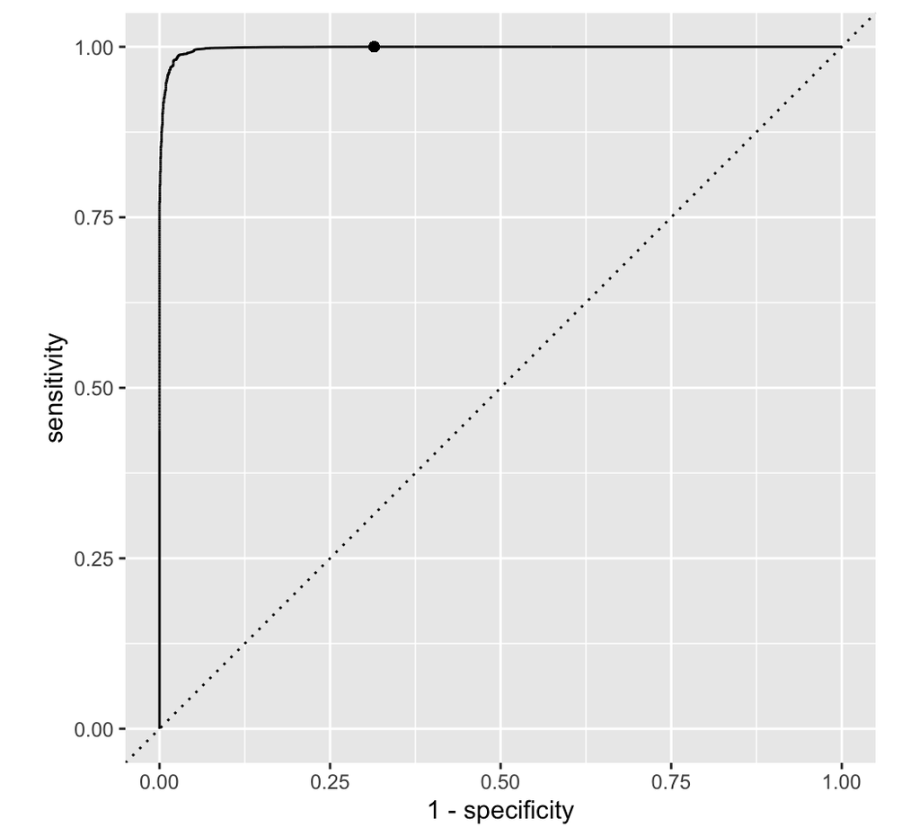

```r
# calculate ideal threshold from ROC
svm.linear.roc <- svm.linear.roc %>% rowid_to_column()
svm.linear.thresh <- svm.linear.roc %>% filter(sensitivity == 1) %>%
  arrange(desc(specificity)) %>% head(1)

# plot ROC
svm.linear.roc %>% ggplot(aes(x = 1 - specificity, y = sensitivity)) +
  geom_path() + geom_abline(lty=3) + coord_equal() +
  #scale_y_continuous(expand = c(0, 0), limits = c(.00,1.05)) +
  geom_point(aes(1-svm.linear.thresh$specificity,svm.linear.thresh$sensitivity))
```

```r
# calculate PR
svm.linear.pr <- svm.linear.pred %>% pr_curve(actual,prediction)
svm.linear.pr
```

```
#> # A tibble: 29,604 x 3
#>    .threshold recall precision
#>         <dbl>  <dbl>     <dbl>
#>  1     Inf     0             1
#>  2       1.00  0.438         1
#>  3       1.00  0.438         1
#>  4       1.00  0.438         1
#>  5       1.00  0.438         1
#>  6       1.00  0.438         1
#>  7       1.00  0.438         1
#>  8       1.00  0.438         1
#>  9       1.00  0.438         1
#> 10       1.00  0.438         1
#> # … with 29,594 more rows
```

```r
svm.linear.pr_auc <- svm.linear.pred %>% pr_auc(actual,prediction)
svm.linear.pr_auc
```

```
#> # A tibble: 1 x 3
#>   .metric .estimator .estimate
#>   <chr>   <chr>          <dbl>
#> 1 pr_auc  binary          1.00
```

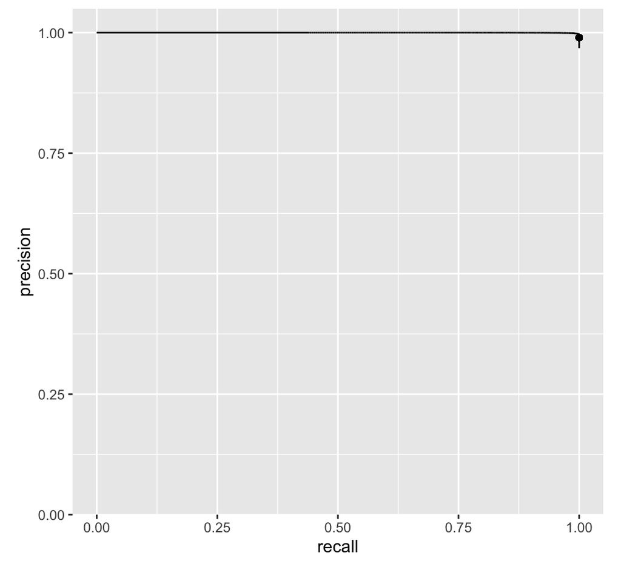

```r
# calculate ideal threshold from PR
svm.linear.pr <- svm.linear.pr %>% rowid_to_column()
svm.linear.thresh.pr <- svm.linear.pr %>% filter(recall == 1) %>%
  arrange(desc(precision)) %>% head(1)
svm.linear.thresh.pr.hp <- svm.linear.pr[1900,]

# plot PR
svm.linear.pr %>% ggplot(aes(x = recall, y = precision)) +
  geom_path() + coord_equal() +
  scale_y_continuous(expand = c(0, 0), limits = c(.00,1.05)) +
  geom_point(aes(svm.linear.thresh.pr$recall,svm.linear.thresh.pr$precision)) #+
```

```r
  #geom_point(aes(svm.linear.pr[1900,]$recall,
  #               svm.linear.pr[1900,]$precision, colour = 'red'))
```